# The first biofilm cultures

## Overview

Created: 2018-08-04.

Parsed: 2018-09-13.

## Aim

Repeat experiments from Schiebel et al. (2017).

- Congo Red
- Calcofluor
- Crystal Violet
- VideoScan

## Materials

Strains used:

- E. coli MG 1655
- 1917 Nissle (EcN)
- 5212
- 5270
- 5271
- 5272
- 5275
- 5276
- 5644

## Methods

We compare results computing the correlation coefficient between results from Schiebel et al. (2017) and new measurements from 2018. Results are annotated as **R2017** and **R2018** respectively.

In the case of a perfect reproduction of an experiment, the correlation coefficient should be 1. If both experiments are giving different results, the correlation coefficient is 0.

To account for normalization and baselining, we are using Spearman's correlation coefficient which relies on ranks instead of raw values.

## Crystal Violet (CV)

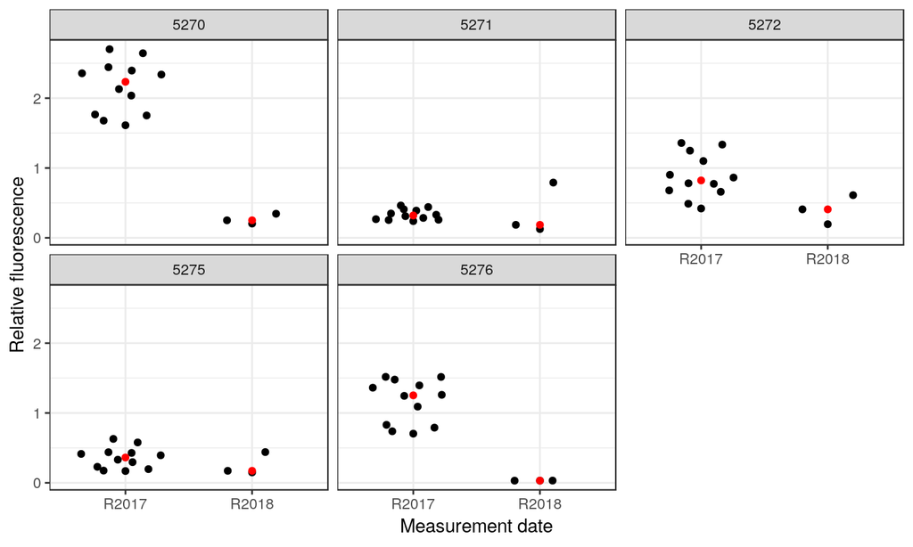

Red points represent medians.

## CV: Pearson's correlation

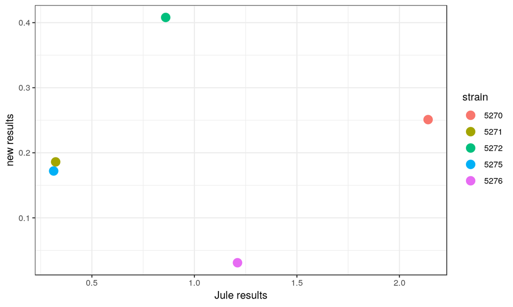

Pearson's correlation: 0.06.

## CV: Spearman's correlation

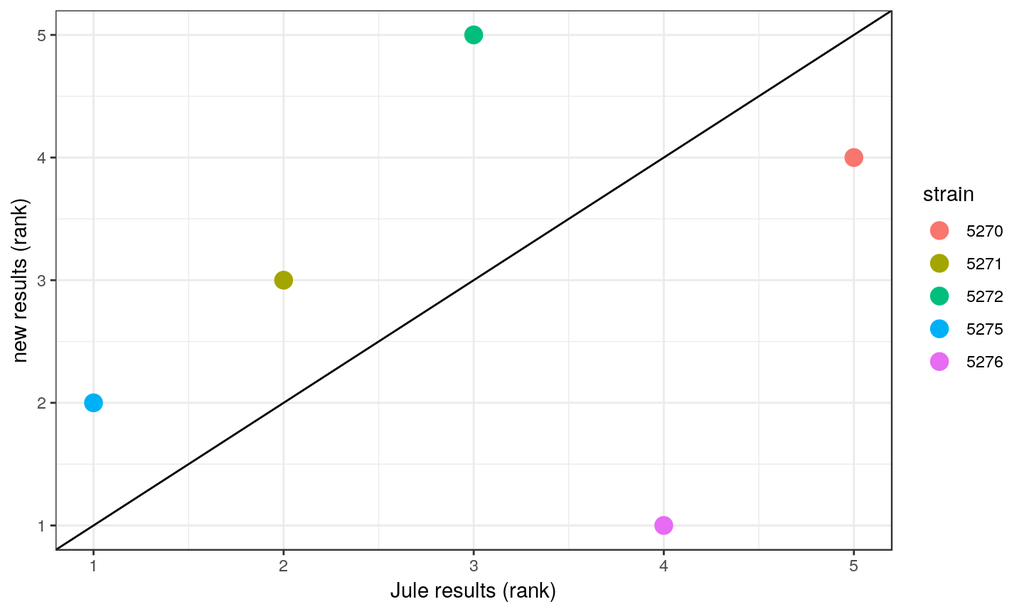

Spearman's correlation (normalization independent): 0.2.

## VideoScan 24 hours

Filename: **ProjektDevC003707-2018-07-26-Koza-Biofilm.csv**.

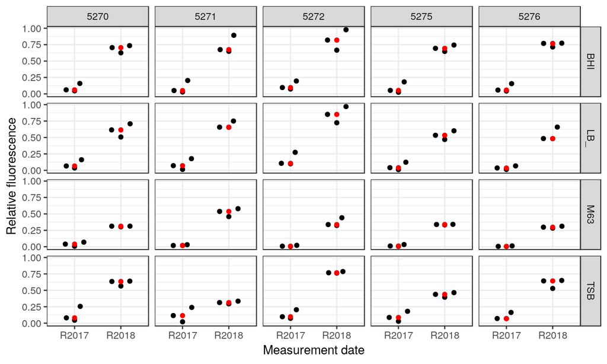

Red points represent medians.

## VS24: Pearson's correlation

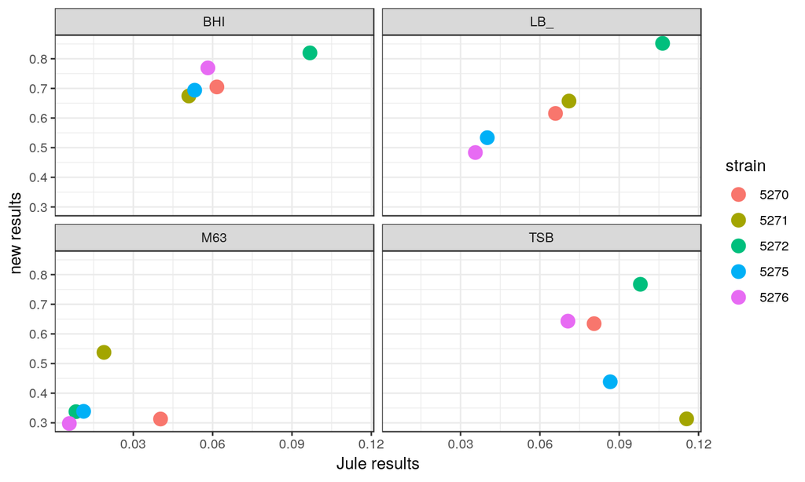

| medium | cor_coef |
| --- | --- |
| BHI | 0.86 |
| LB_ | 0.99 |
| M63 | 0.05 |
| TSB | -0.52 |

## VS24: Spearman's correlation

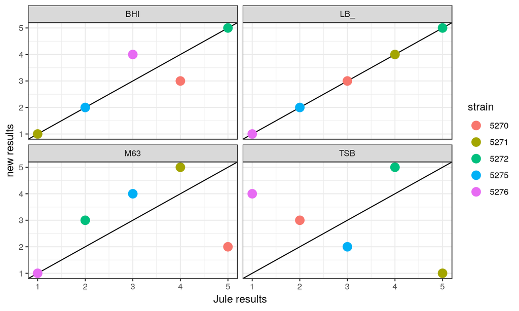

| medium | rho |
| --- | --- |
| BHI | 0.9 |
| LB_ | 1.0 |
| M63 | 0.4 |
| TSB | -0.4 |

## VideoScan 48 hours

Filename: **ProjektDevC003709-2018-07-27-Ania-Biofilm.csv**.

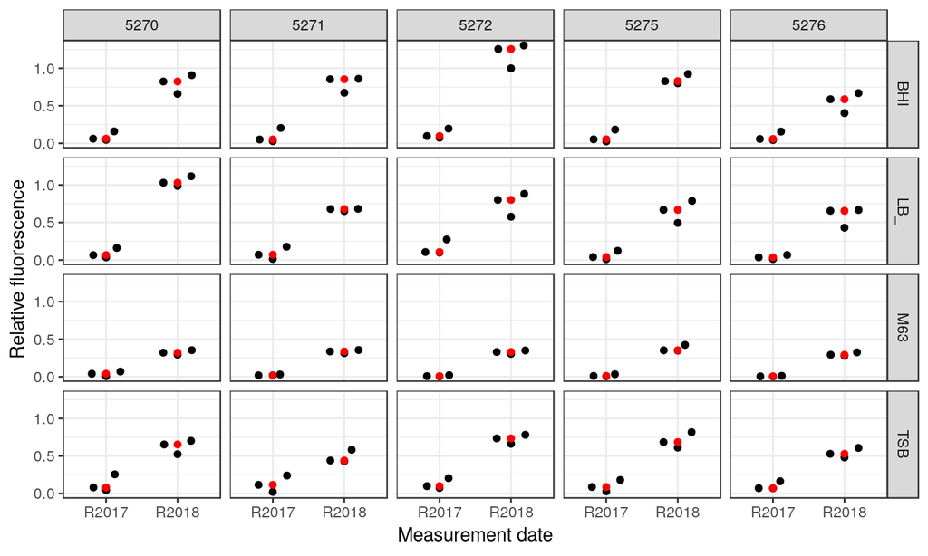

Red points represent medians.

## VS48: Pearson's correlation

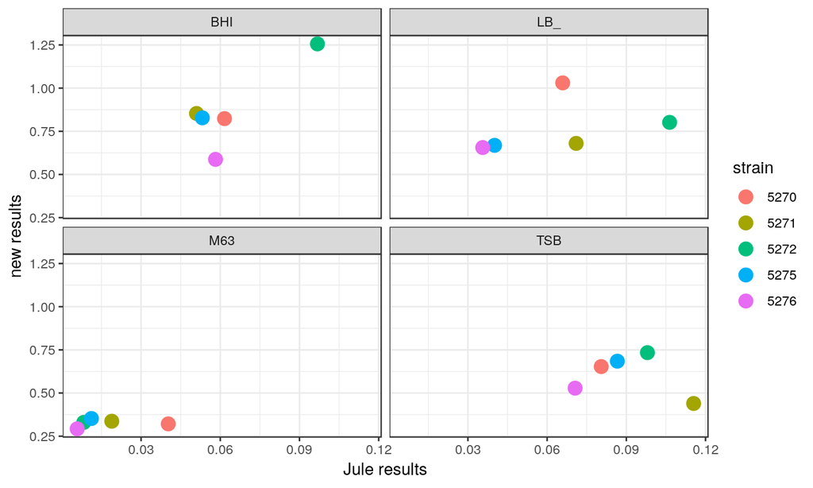

| medium | cor_coef |
| --- | --- |
| BHI | 0.83 |
| LB_ | 0.38 |
| M63 | 0.08 |
| TSB | -0.29 |

## VS48: Spearman's correlation

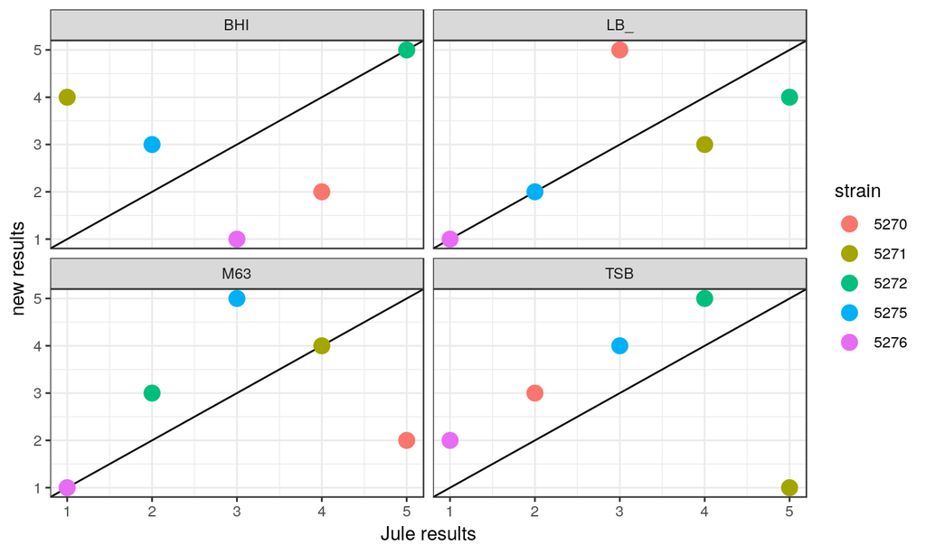

| medium | rho |
| --- | --- |
| BHI | 0.1 |
| LB_ | 0.7 |
| M63 | 0.3 |
| TSB | 0.0 |

## Congo red (CR)

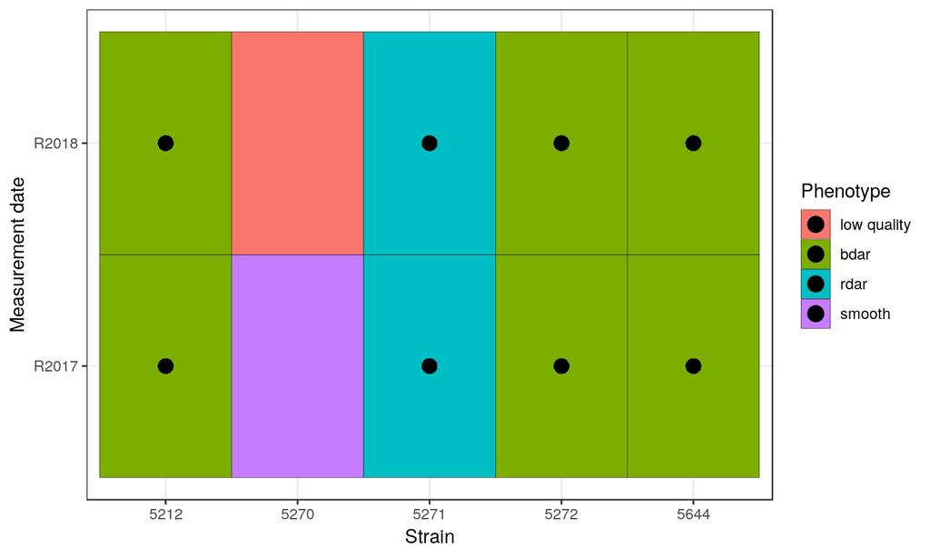

Points denote experiments where results from 2017 and 2018 are in the agreement.

## Congo red (CR)

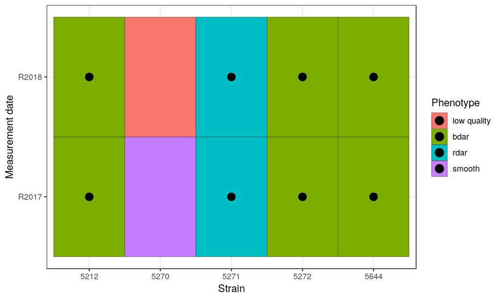

Why there are no CR measurements for strains 5275 and 5276?

## CR (2017 and 2018)

R2018.

[figure not shown]

Improper streaking.

R2017

[figure not shown]

## CR2018

[figure not shown]

## Calcofluor

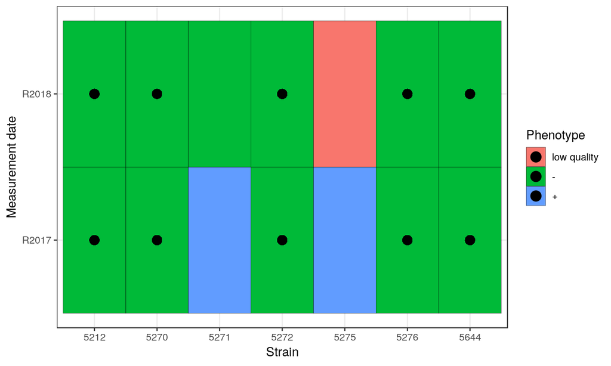

Points denote experiments where results from 2017 and 2018 are in the agreement.

## Calcofluor 2017 and 2018

R2018.

[figure not shown]

Improper streaking - too dense colonies.

R2017

[figure not shown]

## CF2018

[figure not shown]

## Conclusions

1. Repeat experiments (each person separately performs the whole procedure: three replicates of VS and CV and only once CR and CF).
2. Improve quality of data: naming convention of files, put CV, CR and CF results in the electronic format in the dropbox repository.
3. Improve quality of streaking and photos.

## VideoScan 24 hours - 4, column swap

Filename: **ProjektDevC003707-2018-07-26-Koza-Biofilm.csv**.

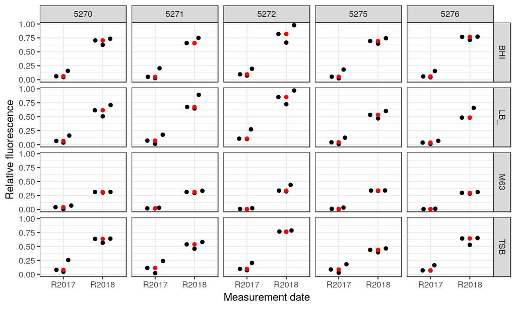

Red points represent medians.

## VS24: Pearson's correlation - 4, column swap

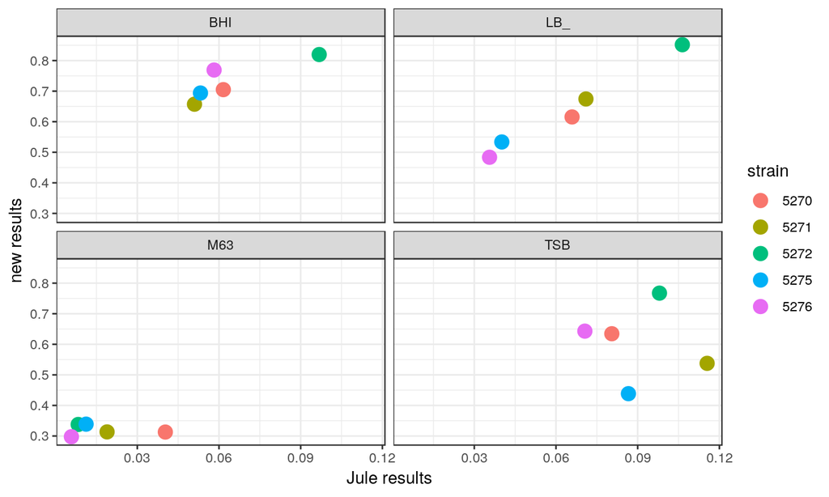

| medium | cor_coef |
| --- | --- |
| BHI | 0.85 |
| LB_ | 0.99 |
| M63 | -0.19 |
| TSB | -0.10 |

## VS24: Spearman's correlation - 4, column swap

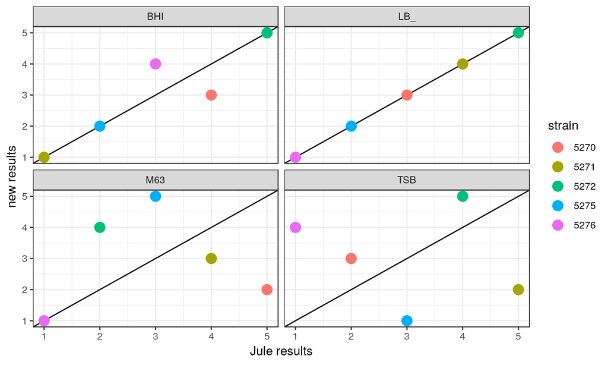

| medium | rho |
| --- | --- |
| BHI | 0.9 |
| LB_ | 1.0 |
| M63 | 0.1 |
| TSB | -0.2 |